# Making EML for the GLEON Lake Chloride dataset (an example)

Colin Smith

2017-06-14

Here we demonstrate use of the EMLassemblyline R code package to create EML for the Global Lakes Ecological Observatory Network (GLEON) Lake Chloride dataset. This data package has been curated with the Environmental Data Initiative (EDI) and is publicly accessible through the EDI data portal of the PASTA repository [here](https://portal.edirepository.org/nis/mapbrowse?scope=edi&identifier=8).

## Install EMLassemblyline

Until this code is apart of CRAN, you will need to install the EMLassemblyline with the devtools package.

```r
install.packages("devtools")
library(devtools)
install_github("EDIorg/EMLassemblyline")
```

## Compile data

The GLEON Lake Chloride has been compiled into 3 entities. Two tables: gleon_chloride_concentrations.csv (a file containing long term chloride concentration data from 529 lakes and reservoirs around North America and Europe), gleon_chloride_lake_characteristics (a file containing lake characteristics, including climate, road density, and impervious surface data) and one zip directory: gleon_chloride_lake_shape_files.zip (Shapefiles that geographically delimited the perimeter of the lakes were required to quantify surrounding land use patterns). We will not cover creating EML for the spatial data in this demonstration.

## Create a dataset working directory

Create a working directory for the dataset and name it using underscore characters “_" to span spaces between words (e.g. gleon_chloride). This directory stores metadata parts created in the assembly line and should be semi-permanent. These files will need to be edited in the event the dataset changes and/or the EML needs revision.

[figure not shown]

## Move data to the working directory

Move the data tables to the dataset working directory and name them following the convention “datasetname_datatablename”, where datasetname is the name of the dataset (e.g. gleon_chloride), and datatablename is the name of the data table (e.g. lake_characteristics). In this example, the data table names become “gleon_chloride_concentrations.csv” and “gleon_chloride_lake_characteristics.csv”.

[figure not shown]

## Import metadata templates

Import metadata templates to the dataset working directory. These metadata templates form the core of the metadata that will be later translated into EML. To import these templates run the import_templates.R function with a path to the working directory.

```r
import_templates(path = "C:\\Users\\Colin\\Desktop\\gleon_chloride")
```

[figure not shown]

For more information about the import_templates.R function run:

```r
?import_templates
```

## Complete the metadata templates

Now that we have the metadata templates imported to the working directory we can begin filling them out. For detailed instructions see the documentation for view_instructions.R and for step by step instructions printed to the RStudio console window run view_instructions.R with no arguments:

```r
?view_instructions  # Opens documentation for this function, including detailed instructions for templates
view_instructions() # Prints instructions to the RStudio console window
```

## Abstract

Write an abstract for the dataset in the file datasetname_abstract.txt. Rename the file following convention (e.g. gleon_chloride_abstract). The abstract should cover what, why, when, where, and how. The template is a UTF-8 formatted file. Use only UTF-8 symbols and text.

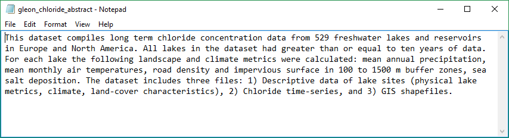

## Additional information

Place additional info in the file datasetname_additional_info.txt. Rename the file following convention (e.g. gleon_chloride_additional_info). This is a good place to share additional text based information that doesn’t fall under the scope of the abstract or methods (e.g. a list of research articles or theses derived from this dataset). The template is a UTF-8 formatted file. Use only UTF-8 symbols and text. Delete this file if there is no additional information to present.

[figure not shown]

## Intellectual rights

Select an intellectual rights license. We have two recommendations: ‘datasetname_cc_by_4.0_intellectual_rights.txt’ and ‘datasetname_cc0_1_intellectual_rights.txt’. Do not edit the text of these files. Delete the file that will not be using. Rename the file being used following convention (e.g. gleon_chloride_intellectual_rights).

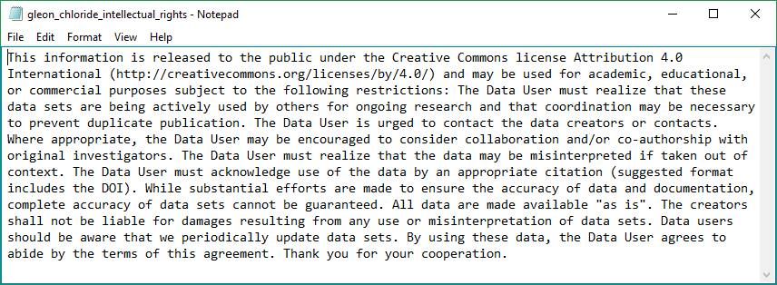

## Methods

Explain the methods used to create this dataset in the file datasetname_methods.txt. Rename this file following convention (e.g. gleon_chloride_methods). Be specific, include instrument descriptions, or point to a protocol online. If this dataset is a synthesis of other datasets please specify dataset origins, preferably their DOI or URL plus general citation information. This file is a UTF-8 formatted file. Use only UTF-8 symbols and text.

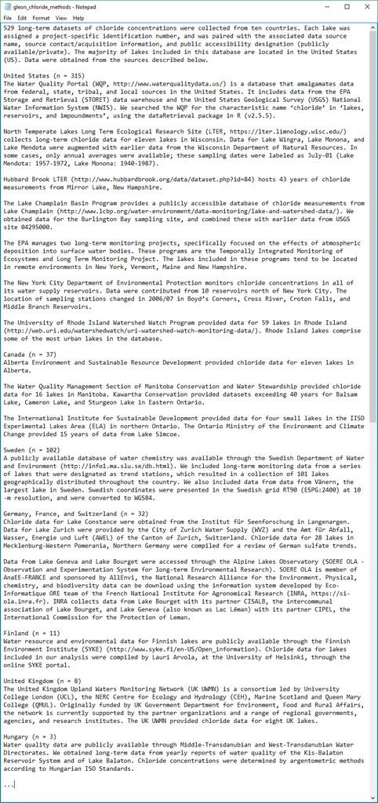

## Personnel information

Enter personnel information for the dataset in the file datasetname_personnel.txt. This is a tab delimited file that can be edited with a spreadsheet editor. Rename the file according to convention (e.g. gleon_chloride_personnel). Valid entries for role are: “creator” = dataset creator, “pi” = principal investigator, “contact” = dataset contact. Any other entries into the ‘role’ column are acceptable and will be defined under the associated party element of this dataset. If a person serves more than one role, duplicate this persons information in another row but with the new role. A dataset creator, contact, and principal investigator are mandatory. This file is a UTF-8 formatted file. Use only UTF-8 symbols and text.

[figure not shown]

## Table attributes

Add data table attributes to the file datasetname_datatablename_attributes.txt. This is a tab delimited file that can be edited with a spreadsheet editor. Rename the file according to convention (e.g. gleon_chloride_lake_characteristics_attributes). Create an attributes file for each data table. This file is a UTF-8 formatted file. Use only UTF-8 symbols and text. Instructions for completing the attribute table are as follows:

- “attributeDefinition” Define the attribute. Be specific, it can be lengthy.
- “class” Specify the attribute class. This is the type of value stored under the attribute. Valid options are: “numeric” for numeric data, “categorical” for categorical variables, “character” for non-categorical data containing text or symbols, and “Date” for date time data. The list of valid options are case sensitive. If an attribute has class of “numeric” or “Date”, then all values of this attribute must be either numeric or date time. If any character strings are present in an otherwise “numeric” attribute, this attribute must be classified as “character”. Similarly if any values of a “Date” attribute do not match the date time format string (details below), then this attribute must be classified as “character”.
- “unit” If an attributes class is numeric, then you must provide units. If the attribute is numeric but does not have units, enter “dimensionless”. If the attribute class is a character or vector, then leave the unit field blank. If the attribute is numeric and has units search the standard unit dictionary (opened in the source window) for the unit of interest and enter the unit “name” as it appears in the dictionary. Unit names are case sensitive. If you cannot find a unit in the dictionary, enter the unit in the tab delimited UTF-8 formatted file datasetname_custom_units.txt. Rename this file to accord with the naming convention (e.g. gleon_chloride_custom_units). Valid custom units must be convertible to SI Units (i.e. International System of Units). If it cannot be converted to SI then list it in the attribute defintion and enter “dimensionless” in the unit field. To create a custom unit define the:
  - “id” This is equivalent to the unit name. Reference the standard unit dictionary formatting.
  - “unitType” The type of unit being defined. Reference the dictionary for examples.
  - “parentSI” The SI equivalent of the id you have entered.
  - “multiplierToSI” This is the multiplier to convert from your custom unit to the SI unit equivalent.
  - “description” A description of the custom unit. Reference the dictionary for examples.
- “dateTimeFormatString” Enter the date time format string for each attribute of “Date” class. Remember, a class of “Date” specifies the attribute as a date, time, or datetime. Enter the format string in this field. If the attribute class is not “Date”, leave this field blank. Below are rules for constructing format strings. Additional information is listed under “dateTime-eml-attribute” of the current EML specification (https://knb.ecoinformatics.org/#external//emlparser/docs/index.html). Valid date time formats are a combination of date, time, and time zone strings. Below are a set of best practice recomendations, and are by no means the full list of acceptable format strings.
  - Date format strings: YYYY-MM-DD, YYYY/MM/DD YYYY, YYYYMMDD, YYYY-MM, YYYY/MM, YYYYMM, YYYY-DDD, YYYY/DDD, YYYYDDD; where YYYY is year, MM is month, DD is day of month, and DDD“is day of year.
  - Time format strings: hh:mm:ss.sss, hhmmss.sss, hh:mm:ss, hhmmss, hh:mm, hhmm, hh; where hh is hour (in 24 hr clock), mm is minute, ss is second, and ss.sss is decimal second.
  - Time zone format strings: Z, +hh:mm, +hhmm, +hh, -hh:mm, -hhmm, -hh; where Z (capitalized) is Coordinated Universal Time, and + and - denote times ahead and behind UTC respectively.

If reporting a date without time, select one of the date format strings. If reporting a date and time, select one date and one time format string and combine with a single space (e.g. YYYY-MM-DD hh:mm) or with a “T” (e.g. YYYY-MM-DDThh:mm). If reporting a date and time, it is recommended that a time zone specifier be appended without a space (e.g. YYYY-MM-DD hh:mm-hh:mm, or YYYY-MM-DDThh:mm-hh:mm).

- “missingValueCode” If a code for ‘no data’ is used, specify it here (e.g. NA, -99999).
- “missingValueCodeExplanation” Define the missing value code here.

[figure not shown]

[figure not shown]

[figure not shown]

## Configuration file

Fill out the file eml_configuration.R. Additional information information about the dataset is stored in this file. Instructions for this file are listed as comments within the file.

[figure not shown]

## Close files of the working directory

Make sure all files of the working directory are closed. Some functions will error out if these files are open. The working directory of this dataset is now populated with the core metadata templates.

[figure not shown]

## Define categorical variables

Since this dataset contains categorical variables we will need to define them using the function define_catvars.R. This function requires a path to the dataset working directory containing the completed attribute templates. The function looks in each attribute file searching for variables of class = “categorical”. Once found the function identifies all uniqe instances of the respective variable and writes them to file for your editing.

```r
define_catvars(path = "C:\\Users\\Colin\\Desktop\\gleon_chloride")
```

The only attributes file containing categorical variables is “gleon_chloride_lake_characteristics_attributes.txt”, and thus only one new file containing categorical variables is written to the working directory (i.e. gleon_chloride_lake_characteristics_catvars.txt“).

[figure not shown]

[figure not shown]